# R Notebook

```r
library(readr)
library(dplyr)
library(ggplot2)
library(stats)
```

```r
# Load Data
df <- read_csv("/Users/jinwens/Desktop/Winter2024/Managerial Analytics/strt-analytics-assignments/GroupAssignment #1/lunchsales-1.csv")
```

```r
summary(df)
```

[output not shown]

```r
# Convert DayOfWeek into a categorical variable with Monday as the baseline
df$DayOfWeek <- relevel(factor(df$DayOfWeek), ref="Monday")
```

```r
# Model 1: Linear regression with lunch sales as the dependent variable
model1 <- lm(NumberOfLunchSales ~ PrecipitationMm + LunchtimeTemperatureCelsius + HumidityPct + HighSeason + NumberOfOpenCompetitors + DayOfWeek, data=df)
summary(model1)
```

```
Call:
lm(formula = NumberOfLunchSales ~ PrecipitationMm + LunchtimeTemperatureCelsius +
    HumidityPct + HighSeason + NumberOfOpenCompetitors + DayOfWeek,
    data = df)

Residuals:
    Min      1Q  Median      3Q     Max
-52.215 -12.179  -0.783  11.816  74.316

Coefficients:
                             Estimate Std. Error
(Intercept)                 176.20695   10.14026
PrecipitationMm              -0.22751    0.07345
LunchtimeTemperatureCelsius  -1.17651    0.14534
HumidityPct                  -0.41824    0.07795
HighSeason                    9.18171    1.96925
NumberOfOpenCompetitors      -1.80049    0.38090
DayOfWeekFriday              -1.92264    2.50380
DayOfWeekSaturday             0.27439    2.52324
DayOfWeekSunday               4.63757    2.50560
DayOfWeekThursday            -2.52401    2.47277
DayOfWeekTuesday             -1.88938    2.50714
DayOfWeekWednesday            1.95978    2.48641
                            t value Pr(>|t|)
(Intercept)                  17.377  < 2e-16 ***
PrecipitationMm              -3.097  0.00203 **
LunchtimeTemperatureCelsius  -8.095 2.53e-15 ***
HumidityPct                  -5.366 1.10e-07 ***
HighSeason                    4.663 3.74e-06 ***
NumberOfOpenCompetitors      -4.727 2.75e-06 ***
DayOfWeekFriday              -0.768  0.44281
DayOfWeekSaturday             0.109  0.91344
DayOfWeekSunday               1.851  0.06461 .
DayOfWeekThursday            -1.021  0.30774
DayOfWeekTuesday             -0.754  0.45134
DayOfWeekWednesday            0.788  0.43085
---
Signif. codes:
0 ‘***’ 0.001 ‘**’ 0.01 ‘*’ 0.05 ‘.’ 0.1 ‘ ’ 1

Residual standard error: 17.82 on 703 degrees of freedom
Multiple R-squared:  0.2162,    Adjusted R-squared:  0.204
F-statistic: 17.63 on 11 and 703 DF,  p-value: < 2.2e-16
```

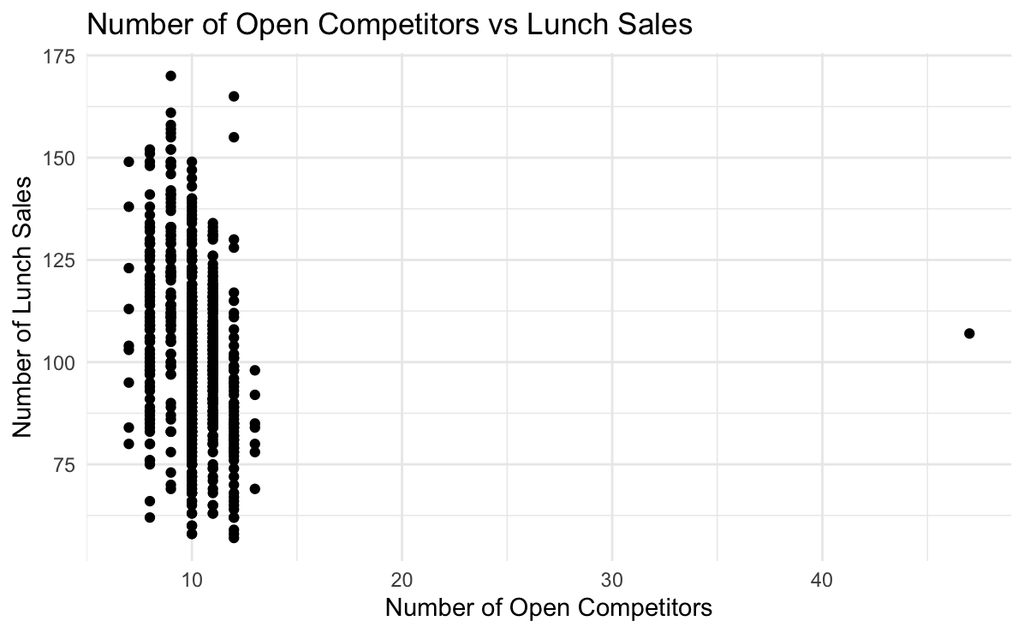

```r
# Creating the plot
ggplot(df, aes(x = NumberOfOpenCompetitors, y = NumberOfLunchSales)) +
  geom_point() +
  theme_minimal() +
  labs(title = "Number of Open Competitors vs Lunch Sales",
       x = "Number of Open Competitors",
       y = "Number of Lunch Sales")
```

1a. The coefficient is -1.80049 and statistically significant, meaning for each additional open competitor, lunch sales decrease by approximately 1.80049, all else equal. This negative relationship makes sense as more competitors are likely to divide the potential customer base in reality. However, the change should not be in absolute numbers because the distribution of competitors is skewed. More than 75% of the competitor count is below 11 with a mean equals to 10.1, while the largest is 47, which could be an outlier or recording error. If we drop the observation where number of competitor and ran the regression again, we are likely to get a better estimate.

```r
# Model 2: Linear regression with log-transformed lunch sales as the dependent variable
df$log_NumberOfLunchSales <- log(df$NumberOfLunchSales)
model2 <- lm(log_NumberOfLunchSales ~ PrecipitationMm + LunchtimeTemperatureCelsius +
             HumidityPct + HighSeason + NumberOfOpenCompetitors + DayOfWeek, data=df)
summary(model2)
```

```
Call:
lm(formula = log_NumberOfLunchSales ~ PrecipitationMm + LunchtimeTemperatureCelsius +
    HumidityPct + HighSeason + NumberOfOpenCompetitors + DayOfWeek,
    data = df)

Residuals:
     Min       1Q   Median       3Q      Max
-0.60324 -0.10871  0.00819  0.12374  0.71528

Coefficients:
                              Estimate Std. Error t value Pr(>|t|)
(Intercept)                  5.2891861  0.1005467  52.604  < 2e-16 ***
PrecipitationMm             -0.0023633  0.0007283  -3.245  0.00123 **
LunchtimeTemperatureCelsius -0.0109379  0.0014412  -7.590 1.02e-13 ***
HumidityPct                 -0.0039617  0.0007729  -5.126 3.84e-07 ***
HighSeason                   0.1050068  0.0195263   5.378 1.03e-07 ***
NumberOfOpenCompetitors     -0.0165261  0.0037768  -4.376 1.39e-05 ***
DayOfWeekFriday             -0.0272957  0.0248266  -1.099  0.27195
DayOfWeekSaturday           -0.0055955  0.0250194  -0.224  0.82310
DayOfWeekSunday              0.0303279  0.0248445   1.221  0.22261
DayOfWeekThursday           -0.0274645  0.0245190  -1.120  0.26304
DayOfWeekTuesday            -0.0174056  0.0248597  -0.700  0.48406
DayOfWeekWednesday           0.0157933  0.0246542   0.641  0.52200
---
Signif. codes:  0 ‘***’ 0.001 ‘**’ 0.01 ‘*’ 0.05 ‘.’ 0.1 ‘ ’ 1

Residual standard error: 0.1767 on 703 degrees of freedom
Multiple R-squared:  0.2137,    Adjusted R-squared:  0.2013
F-statistic: 17.36 on 11 and 703 DF,  p-value: < 2.2e-16
```

1b. The coefficient is -0.0165261 and statistically significant. This coeficient means that for each additional open competitor, lunch sales decrease by approximately 1.64%. This means that sales tend to be lower by 1.64% for each extra competitor, all other factors being constant. Similar issue discussed in 1a could impact our estimation using a logit model.

Here are the regression without the outlier number of competitor count.

```r
# Apply filter
df_filtered <- df %>% filter(NumberOfOpenCompetitors != 47)
```

```r
model3 <- lm(NumberOfLunchSales ~ PrecipitationMm + LunchtimeTemperatureCelsius + HumidityPct + HighSeason + NumberOfOpenCompetitors + DayOfWeek, data=df_filtered)
summary(model3)
```

```
Call:
lm(formula = NumberOfLunchSales ~ PrecipitationMm + LunchtimeTemperatureCelsius +
    HumidityPct + HighSeason + NumberOfOpenCompetitors + DayOfWeek,
    data = df_filtered)

Residuals:
    Min      1Q  Median      3Q     Max
-52.022 -11.469  -0.172  10.888  62.907

Coefficients:
                             Estimate Std. Error t value Pr(>|t|)
(Intercept)                 211.67389   11.12860  19.021  < 2e-16 ***
PrecipitationMm              -0.20429    0.07128  -2.866  0.00428 **
LunchtimeTemperatureCelsius  -1.16084    0.14091  -8.238 8.54e-16 ***
HumidityPct                  -0.47931    0.07609  -6.299 5.28e-10 ***
HighSeason                    8.05477    1.91604   4.204 2.96e-05 ***
NumberOfOpenCompetitors      -4.82419    0.57814  -8.344 3.79e-16 ***
DayOfWeekFriday              -1.82722    2.42704  -0.753  0.45179
DayOfWeekSaturday             0.27275    2.44585   0.112  0.91124
DayOfWeekSunday               4.63853    2.42875   1.910  0.05656 .
DayOfWeekThursday            -2.59123    2.39695  -1.081  0.28004
DayOfWeekTuesday             -2.02601    2.43032  -0.834  0.40477
DayOfWeekWednesday            1.13694    2.41319   0.471  0.63769
---
Signif. codes:  0 ‘***’ 0.001 ‘**’ 0.01 ‘*’ 0.05 ‘.’ 0.1 ‘ ’ 1

Residual standard error: 17.27 on 702 degrees of freedom
Multiple R-squared:  0.2646,    Adjusted R-squared:  0.253
F-statistic: 22.96 on 11 and 702 DF,  p-value: < 2.2e-16
```

```r
model4 <- lm(log_NumberOfLunchSales ~ PrecipitationMm + LunchtimeTemperatureCelsius +
             HumidityPct + HighSeason + NumberOfOpenCompetitors + DayOfWeek, data=df_filtered)
summary(model4)
```

```
Call:
lm(formula = log_NumberOfLunchSales ~ PrecipitationMm + LunchtimeTemperatureCelsius +
    HumidityPct + HighSeason + NumberOfOpenCompetitors + DayOfWeek,
    data = df_filtered)

Residuals:
     Min       1Q   Median       3Q      Max
-0.60138 -0.10199  0.01329  0.11752  0.48891

Coefficients:
                              Estimate Std. Error t value Pr(>|t|)
(Intercept)                  5.6305514  0.1105561  50.929  < 2e-16 ***
PrecipitationMm             -0.0021398  0.0007081  -3.022   0.0026 **
LunchtimeTemperatureCelsius -0.0107872  0.0013998  -7.706 4.43e-14 ***
HumidityPct                 -0.0045494  0.0007559  -6.019 2.83e-09 ***
HighSeason                   0.0941601  0.0190347   4.947 9.45e-07 ***
NumberOfOpenCompetitors     -0.0456289  0.0057435  -7.944 7.76e-15 ***
DayOfWeekFriday             -0.0263773  0.0241112  -1.094   0.2743
DayOfWeekSaturday           -0.0056113  0.0242981  -0.231   0.8174
DayOfWeekSunday              0.0303371  0.0241282   1.257   0.2091
DayOfWeekThursday           -0.0281115  0.0238123  -1.181   0.2382
DayOfWeekTuesday            -0.0187207  0.0241438  -0.775   0.4384
DayOfWeekWednesday           0.0078735  0.0239736   0.328   0.7427
---
Signif. codes:  0 ‘***’ 0.001 ‘**’ 0.01 ‘*’ 0.05 ‘.’ 0.1 ‘ ’ 1

Residual standard error: 0.1716 on 702 degrees of freedom
Multiple R-squared:  0.2593,    Adjusted R-squared:  0.2477
F-statistic: 22.34 on 11 and 702 DF,  p-value: < 2.2e-16
```

Based on model 3 and model 4, we found including the outlier caused us to underestaimte the effects of competitors on sales.

After data cleaning, our answer for 1a and 1 be is the folloiwng:

Improved 1a: The coefficient is -4.82419 and statistically significant, meaning for each additional open competitor, lunch sales decrease by approximately 4.82419, all else equal. This negative relationship makes sense as more competitors are likely to divide the potential customer base in reality.

Improved 1b: The coefficient is -0.0456289 and statistically significant. This coeficient means that for each additional open competitor, lunch sales decrease by approximately 4.56%. This means that sales tend to be lower by 4.56% for each extra competitor, all other factors being constant.

1c. One potential omitted variable in this context could be the consumer spending power. This variable represents the general economic health of the area where the restaurant is located and the disposable income of potential customers. It’s a crucial factor because people’s willingness and ability to dine out is significantly influenced by their financial situation. We expect the omitted variable is positive correlated with lunch sales. Generally, better economic conditions or higher consumer spending power means that people are more likely to eat out, increasing lunch sales.

Economic conditions could also be correlated with some of the included variables. For example, the number of open competitors could be influenced by the local economy, with more businesses thriving in a robust economic environment.

If local economic conditions are not included in the model, and they are positively correlated with both the dependent variable (lunch sales) and one or more of the independent variables, the coefficients of these variables might be overestimated. This is because part of the effect of the local economic conditions on lunch sales might be incorrectly attributed to these variables.

2. *Monday has served as a baseline against which sales on other days are compared.

For example, the coefficient for Sunday is 4.63853, which would suggest that on Sundays, all else being equal, lunch sales are expected to be higher by approximately 4.64 units compared to Monday.

Use model 3 to proceed.

```r
coef_model <- summary(model3)$coefficients

# Extract coefficients and standard errors
sunday_coef <- coef_model["DayOfWeekSunday", "Estimate"]
sunday_se <- coef_model["DayOfWeekSunday", "Std. Error"]

thursday_coef <- coef_model["DayOfWeekThursday", "Estimate"]
thursday_se <- coef_model["DayOfWeekThursday", "Std. Error"]

# Calculate the difference and its standard error
diff_coef <- sunday_coef - thursday_coef
diff_se <- sqrt(sunday_se^2 + thursday_se^2)

# Calculate the 95% confidence interval of the difference
lower_bound <- diff_coef - 1.96 * diff_se
upper_bound <- diff_coef + 1.96 * diff_se

list(Difference = diff_coef, LowerBound = lower_bound, UpperBound = upper_bound)
```

```
$Difference
[1] 7.229762

$LowerBound
[1] 0.5415445

$UpperBound
[1] 13.91798
```

The interval does not contain zero, it suggests that the difference is statistically significant.

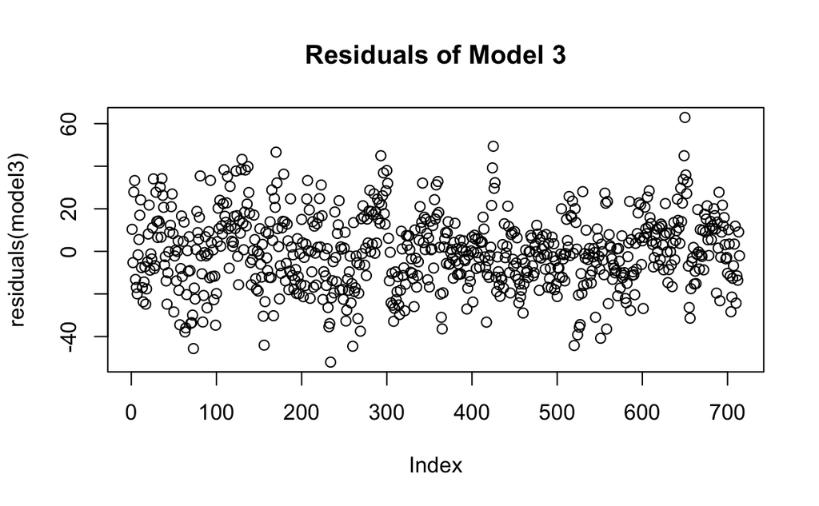

```r
# Residual analysis for Model 1
plot(residuals(model3), main="Residuals of Model 3")
```

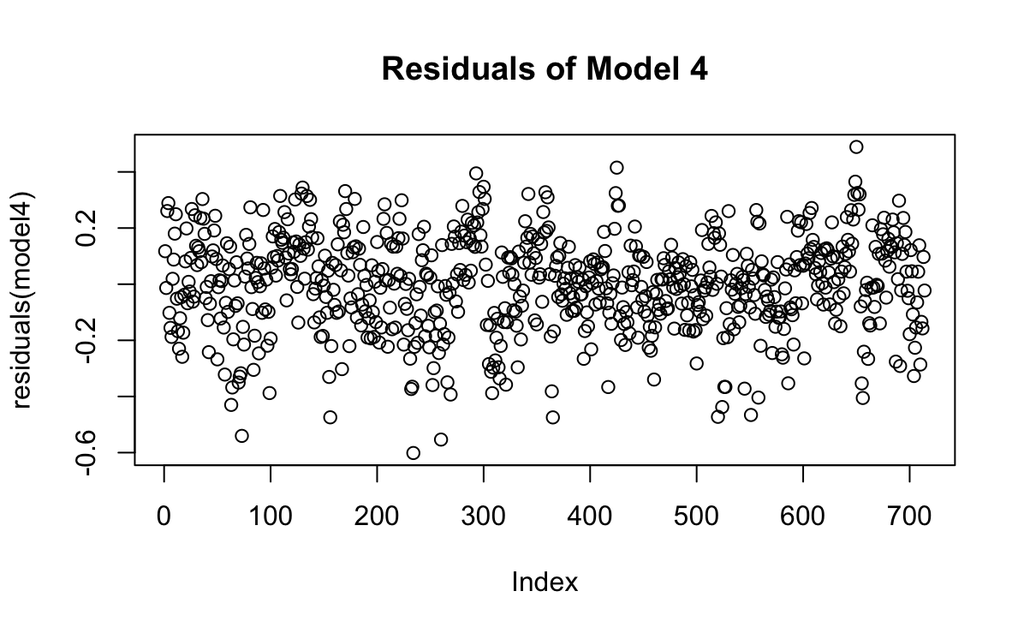

```r
# Residual analysis for Model 2
plot(residuals(model4), main="Residuals of Model 4")
```

Model 3 Residuals The residuals for Model 3 appear to be scattered without a clear pattern in terms of increasing or decreasing variance, which is a good sign. However, there’s a wide spread of residuals, which suggests there might be some outliers or high-leverage points that could be disproportionately influencing the model’s estimates.

Model 4 Residuals For Model 4, the residuals seem to be more evenly distributed around zero without apparent patterns or trends, which suggests that the log transformation of the dependent variable might have helped to stabilize the variance of the residuals (homoscedasticity) and improve the model fit.